# Professional sanctions in AI hallucination cases

Group members: Ishita Jain, Ahlam Negash, Abigail Minin

GitHub repository: [View our GitHub repository](https://github.com/ishitajain21/stat-learning-group-analysis)

Partner 1: Ishita Jain — research question, exploratory analysis, decision tree.

Partner 2: random forest, comparison, conclusions (name to be confirmed).

## Partner 1: Research question

Can party type, jurisdiction, AI-tool identification, and primary legal field classify whether a documented AI hallucination case records a professional sanction? The response is `Professional Sanction`, with Yes as the positive class. This replaces the starter’s question about counts over time to meet the assignment’s classification requirement.

The data come from Damien Charlotin’s AI Hallucination Cases Database. Each row represents a documented case, not a randomly sampled use of AI. We predict the recorded label; No does not rule out later sanctions.

## Partner 1: Exploratory analysis

```r
cases <- read_csv("data/hallucination_cases.csv")
knitr::kable(cases |> count(`Professional Sanction`, name = "Cases"))
```

| Professional Sanction | Cases |
| --- | --- |
| No | 1915 |
| Yes | 163 |

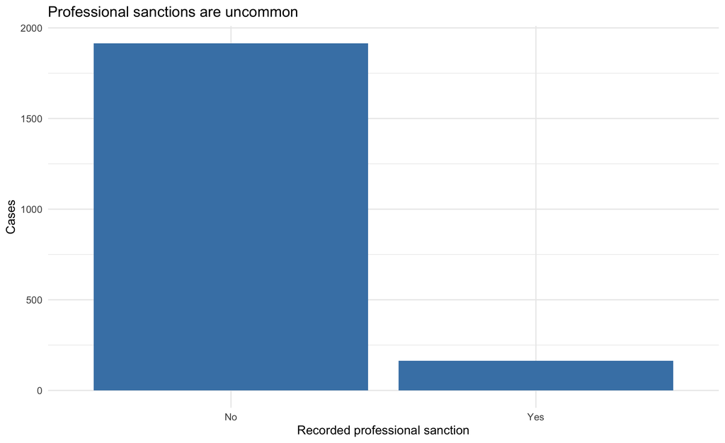

```r
model_data <- cases |>
  filter(`Professional Sanction` %in% c("No", "Yes")) |>
  transmute(
    sanction = factor(`Professional Sanction`, levels = c("No", "Yes")),
    party = case_when(
      str_detect(str_to_lower(coalesce(`Party(ies)`, "")), "lawyer|prosecutor|defender") ~ "Lawyer involved",
      str_detect(str_to_lower(coalesce(`Party(ies)`, "")), "pro se") ~ "Pro se litigant",
      is.na(`Party(ies)`) ~ "Unknown",
      TRUE ~ "Other party"),
    jurisdiction = case_when(`State(s)` == "USA" ~ "USA",
                             is.na(`State(s)`) ~ "Unknown", TRUE ~ "Outside USA"),
    tool = case_when(str_to_lower(`AI Tool`) == "chatgpt" ~ "ChatGPT",
                    str_to_lower(`AI Tool`) %in% c("implied", "unidentified") | is.na(`AI Tool`) ~ "Unspecified or implied",
                    TRUE ~ "Other named tool"),
    legal_field = coalesce(`Legal Field Primary`, "Unknown"))
sanction_rate <- mean(model_data$sanction == "Yes")
ggplot(model_data, aes(sanction)) + geom_bar(fill = "steelblue") +
  labs(x = "Recorded professional sanction", y = "Cases",
       title = "Professional sanctions are uncommon") + theme_minimal()
```

```r
party_summary <- model_data |> group_by(party) |>
  summarise(Cases = n(), Yes = sum(sanction == "Yes"),
            Sanction_rate = mean(sanction == "Yes"), .groups = "drop")
knitr::kable(party_summary, digits = 3)
```

| party | Cases | Yes | Sanction_rate |
| --- | --- | --- | --- |
| Lawyer involved | 835 | 159 | 0.190 |
| Other party | 43 | 2 | 0.047 |
| Pro se litigant | 1194 | 2 | 0.002 |
| Unknown | 6 | 0 | 0.000 |

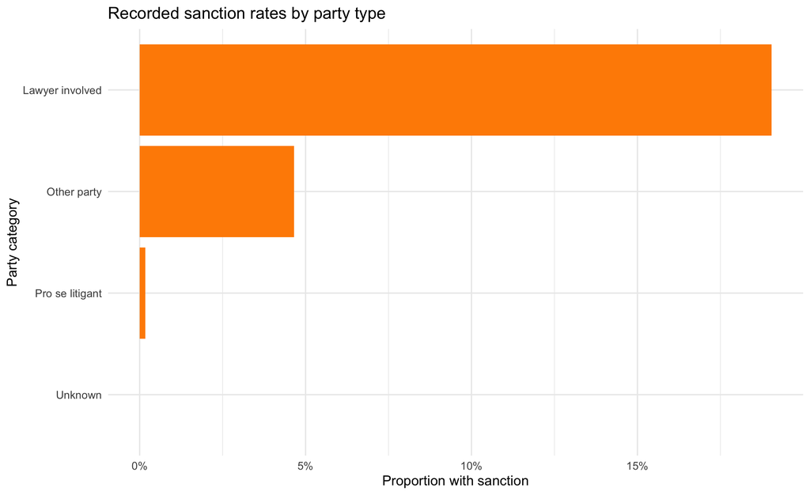

```r
ggplot(party_summary, aes(reorder(party, Sanction_rate), Sanction_rate)) +
  geom_col(fill = "darkorange") + coord_flip() +
  scale_y_continuous(labels = scales::percent) +
  labs(x = "Party category", y = "Proportion with sanction",
       title = "Recorded sanction rates by party type") + theme_minimal()
```

There are 2078 cases; 0 are excluded for missing or unrecognized responses. Among retained cases, 7.84% record a sanction. The imbalanced response means high accuracy can conceal poor detection of Yes cases. The party chart compares rates rather than counts to account for category sizes. Lawyer involvement may be informative because professional discipline applies to legal professionals. These associations do not establish causation.

## Shared modeling setup

```r
set.seed(154)
train_id <- sample(seq_len(nrow(model_data)), round(0.7 * nrow(model_data)))
train <- model_data[train_id, ]
test <- model_data[-train_id, ]
# Learn common fields from training data only; group unseen test levels.
common_fields <- train |> count(legal_field, sort = TRUE) |>
  slice_head(n = 8) |> pull(legal_field)
prepare_predictors <- function(d) {
  d |> mutate(
    legal_field = factor(ifelse(legal_field %in% common_fields, legal_field, "Other"),
                         levels = c(common_fields, "Other")),
    party = factor(party, levels = c("Lawyer involved", "Pro se litigant", "Other party", "Unknown")),
    jurisdiction = factor(jurisdiction, levels = c("USA", "Outside USA", "Unknown")),
    tool = factor(tool, levels = c("ChatGPT", "Unspecified or implied", "Other named tool")))
}
train <- prepare_predictors(train)
test <- prepare_predictors(test)
model_formula <- sanction ~ party + jurisdiction + tool + legal_field
knitr::kable(data.frame(Set = c("Training", "Test"),
                       Cases = c(nrow(train), nrow(test)),
                       Yes_rate = c(mean(train$sanction == "Yes"), mean(test$sanction == "Yes"))), digits = 3)
```

| Set | Cases | Yes_rate |
| --- | --- | --- |
| Training | 1455 | 0.080 |
| Test | 623 | 0.074 |

The seed-154 70/30 split gives 1455 training and 623 test cases. Partner 2 must reuse these processed sets and `model_formula`. Outcome text, monetary penalties, and case narratives are excluded because they could reveal the response; names and source links are also excluded. This is a retrospective random holdout, not a forecast of future cases.

## Partner 1: Decision tree

```r
set.seed(154)
tree_full <- rpart(model_formula, data = train, method = "class",
                   parms = list(split = "gini"),
                   control = rpart.control(cp = 0.001, xval = 10))
printcp(tree_full)
```

```
Classification tree:
rpart(formula = model_formula, data = train, method = "class",
    parms = list(split = "gini"), control = rpart.control(cp = 0.001,
        xval = 10))

Variables actually used in tree construction:
[1] jurisdiction legal_field  party        tool

Root node error: 117/1455 = 0.080412

n= 1455

        CP nsplit rel error xerror     xstd
1 0.011966      0   1.00000 1.0000 0.088655
2 0.008547      5   0.94017 1.0342 0.090023
3 0.001000      6   0.93162 1.0256 0.089684
```

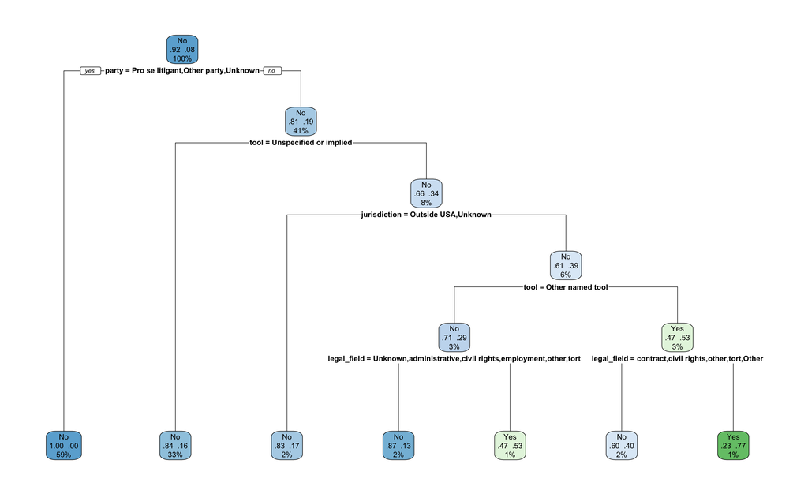

```r
best_cp <- tree_full$cptable[which.min(tree_full$cptable[, "xerror"]), "CP"]
tree_cv <- prune(tree_full, cp = best_cp)
# Prespecified exploratory tree; test data do not choose its settings.
tree_model <- tree_full
rpart.plot(tree_model, extra = 104, fallen.leaves = TRUE)
```

```r
tree_model
```

```
n= 1455

node), split, n, loss, yval, (yprob)
      * denotes terminal node

 1) root 1455 117 No (0.919587629 0.080412371)
   2) party=Pro se litigant,Other party,Unknown 859   2 No (0.997671711 0.002328289) *
   3) party=Lawyer involved 596 115 No (0.807046980 0.192953020)
     6) tool=Unspecified or implied 480  76 No (0.841666667 0.158333333) *
     7) tool=ChatGPT,Other named tool 116  39 No (0.663793103 0.336206897)
      14) jurisdiction=Outside USA,Unknown 29   5 No (0.827586207 0.172413793) *
      15) jurisdiction=USA 87  34 No (0.609195402 0.390804598)
        30) tool=Other named tool 49  14 No (0.714285714 0.285714286)
          60) legal_field=Unknown,administrative,civil rights,employment,other,tort 30   4 No (0.866666667 0.133333333) *
          61) legal_field=contract,Other 19   9 Yes (0.473684211 0.526315789) *
        31) tool=ChatGPT 38  18 Yes (0.473684211 0.526315789)
          62) legal_field=contract,civil rights,other,tort,Other 25  10 No (0.600000000 0.400000000) *
          63) legal_field=Unknown,administrative,employment 13   3 Yes (0.230769231 0.769230769) *
```

```r
leaf_count <- sum(tree_model$frame$var == "<leaf>")
root_variable <- tree_model$frame$var[1]
if (root_variable != "<leaf>") {
  root_paths <- path.rpart(tree_model, nodes = c(2, 3), print.it = FALSE)
  knitr::kable(data.frame(
    Rule = vapply(root_paths, function(x) tail(x, 1), character(1)),
    Cases = tree_model$frame[c("2", "3"), "n"],
    Yes_probability = tree_model$frame$yval2[match(c("2", "3"), rownames(tree_model$frame)), 5]), digits = 3)
}
```

|  | Rule | Cases | Yes_probability |
| --- | --- | --- | --- |
| 2 | party=Pro se litigant,Other party,Unknown | 859 | 0.002 |
| 3 | party=Lawyer involved | 596 | 0.193 |

```r
leaf_id <- as.integer(rownames(tree_model$frame)[which(tree_model$frame$var == "<leaf>")[1]])
leaf_path <- path.rpart(tree_model, nodes = leaf_id, print.it = FALSE)[[1]]
leaf_row <- match(as.character(leaf_id), rownames(tree_model$frame))
leaf_class <- levels(train$sanction)[tree_model$frame$yval[leaf_row]]
leaf_probability <- tree_model$frame$yval2[leaf_row, 5]
```

The tree reduces Gini impurity to create more homogeneous sanction groups. The exploratory tree uses a prespecified CP of 0.001 and has 7 terminal nodes. Training-only ten-fold cross-validation instead selects CP = 0.01197, yielding 1 terminal nodes. Its preference for a single-node tree shows that these splits do not improve cross-validated overall error enough to justify their complexity. We interpret the larger tree as exploratory; the test set does not choose its settings. The first split uses party. The table shows its routing rules and the training sanction proportions on each side. The child with the larger Yes probability records sanctions more often.

One terminal node follows party=Pro se litigant,Other party,Unknown. It predicts No, with estimated Yes probability 0.002. This is a training-node proportion, not certainty about an individual case.

```r
if (length(tree_full$variable.importance)) {
  vi <- sort(tree_full$variable.importance, decreasing = TRUE)
  knitr::kable(data.frame(Predictor = names(vi), Importance = as.numeric(vi)), digits = 2)
}
```

| Predictor | Importance |
| --- | --- |
| party | 25.57 |
| tool | 10.84 |
| legal_field | 7.68 |
| jurisdiction | 2.17 |

Importance values from the candidate tree measure split improvements, including surrogate contributions. They have no sign and are not causal effects.

## Partner 1: Held-out performance

```r
classification_metrics <- function(prediction, actual) {
  cm <- table(Predicted = factor(prediction, levels = c("No", "Yes")),
              Actual = factor(actual, levels = c("No", "Yes")))
  sensitivity <- cm["Yes", "Yes"] / sum(cm[, "Yes"])
  specificity <- cm["No", "No"] / sum(cm[, "No"])
  c(Accuracy = sum(diag(cm)) / sum(cm), Error = 1 - sum(diag(cm)) / sum(cm),
    Sensitivity = sensitivity, Specificity = specificity,
    Balanced_accuracy = mean(c(sensitivity, specificity)))
}
tree_prob <- predict(tree_model, test, type = "prob")[, "Yes"]
tree_class <- factor(ifelse(tree_prob >= 0.5, "Yes", "No"), levels = c("No", "Yes"))
tree_cm <- table(Predicted = tree_class, Actual = test$sanction)
tree_cm
```

```
         Actual
Predicted  No Yes
      No  572  41
      Yes   5   5
```

```r
tree_metrics <- classification_metrics(tree_class, test$sanction)
baseline_metrics <- classification_metrics(rep("No", nrow(test)), test$sanction)
knitr::kable(rbind(Decision_tree = tree_metrics, Always_No = baseline_metrics), digits = 3)
```

|  | Accuracy | Error | Sensitivity | Specificity | Balanced_accuracy |
| --- | --- | --- | --- | --- | --- |
| Decision_tree | 0.926 | 0.074 | 0.109 | 0.991 | 0.55 |
| Always_No | 0.926 | 0.074 | 0.000 | 1.000 | 0.50 |

At a 0.5 Yes-probability cutoff, test accuracy is 92.62%, versus 92.62% for always predicting No. Sensitivity is 10.87%: the proportion of recorded Yes cases correctly identified. Specificity is 99.13%, the proportion of recorded No cases correctly identified. Balanced accuracy is 55%, giving both classes equal weight.

The cross-validation result favors the majority-class baseline over a complex tree, so the exploratory splits should not be treated as a validated improvement. The confusion matrix and sensitivity are essential because predicting No can yield high accuracy. The tree gives readable rules, but rare positives and small leaves can limit reliable detection. Reporting practices, different jurisdictional rules, and later changes in outcomes limit these results. Related cases or repeated parties can make a random holdout more optimistic than prediction for entirely new parties. These results describe this database, not sanction rates among all filings or causal effects of AI tools.